# Zoo Pop Demo Makeup

```r
library(htmlwidgets)
library(plotly)
library(tidyverse)
library(visNetwork)
library(zoopop)
knitr::opts_chunk$set(
  collapse = TRUE,
  message  = FALSE,
  warning  = FALSE,
  echo     = TRUE,
  include  = TRUE,
  eval     = TRUE,
  comment  = ""
)
conflicted::conflicts_prefer(lubridate::interval)
```

```
## [conflicted] Will prefer lubridate::interval over any other package.
```

```r
conflicted::conflicts_prefer(dplyr::filter)
```

```
## [conflicted] Will prefer dplyr::filter over any other package.
```

```r
conflicted::conflicts_prefer(purrr::set_names)
```

```
## [conflicted] Will prefer purrr::set_names over any other package.
```

```r
studbook <- read_csv("studbook.csv")
```

# Instructions

You may choose any of the code chunks in this document to include/exclude from your portfolio. After you are finished, select any three graphics/statistics that tell you something useful for planning an institutional collection or breeding pair. Write a few sentences about why that information is relevant and what pattern you see in the data. Add that to your online submission, along with this file.

# Studbook Overview

Let’s take a quick glance at our studbook data loaded in the setup chunk.

```r
print(studbook)
# A tibble: 820 × 28
      ID name_spec Date_birth Date       Event    Date_last  Status Loc_event
   <dbl> <chr>     <date>     <date>     <chr>    <date>     <chr>  <chr>
 1  1000 <NA>      1984-01-01 1986-01-01 transfer 1987-12-01 D      SKA
 2  1000 <NA>      1984-01-01 1986-12-01 breed    1987-12-01 D      SKA
 3  1001 <NA>      1983-01-01 1985-01-01 transfer 1987-01-01 D      SKA
 4  1001 <NA>      1983-01-01 1986-01-01 breed    1987-01-01 D      SKA
 5  1002 <NA>      1965-06-10 1967-06-10 transfer 1984-04-28 D      USD
 6  1002 <NA>      1965-06-10 1968-06-10 transfer 1984-04-28 D      HON
 7  1003 <NA>      1968-01-05 1970-01-05 transfer 1982-01-29 D      HON
 8  1004 <NA>      1970-10-18 1972-10-18 transfer 1973-10-18 D      HON
 9  1005 <NA>      1970-10-18 1972-10-18 transfer 1973-10-18 D      HON
10  1006 <NA>      1989-01-01 1989-01-01 transfer 1991-06-12 D      PUB
# ℹ 810 more rows
# ℹ 20 more variables: Loc_birth <chr>, Loc_last <chr>, Sex <chr>, Sire <dbl>,
#   Dam <dbl>, age_event <dbl>, age_last <dbl>, Type_birth <chr>,
#   exclude <chr>, Year_birth <dbl>, Institution_birth <chr>,
#   State_Province_birth <chr>, Country_birth <chr>, iconLoc_birth <chr>,
#   colorLoc_birth <chr>, Institution_last <chr>, State_Province_last <chr>,
#   Country_last <chr>, iconLoc_last <chr>, colorLoc_last <chr>
```

## Summarize Demographic Trends

Let’s look at the basic population size over time to begin quantifying growth rate and assessing overall population viability.

```r
population.plot <- plot_census(studbook)
population.plot
```

[interactive chart not shown]

## Demographic Summary

> **Note:** You can play around with the values for the `cohort_params` list in this chunk to change the cohort bins and the overall scale of your analysis. >**Values available in this list:** `Year_min` (the earliest year to include for analysis), `Year_max` (the latest year to include), `span` (the interval in years to use for lumping individuals into generational cohorts, based on their birth year), `age_max` (the maximum age in years to include when forming cohort bins) >**Default values** - if you leave any/all values blank, the following defaults will be used: `Year_min =` *minimum birth year found in studbook*, `Year_min =` *current year*, `span = 10` (*individuals lumped into cohorts based on the decade of their birth*), `age_max =` *maximum age in years observed in studbook records*.

```r
demog <- cohort_demog(studbook, cohort_params = list(span = 5))
print(demog)
# A tibble: 396 × 33
   Cohort_period Cohort_years Cohort Cohort_label Sex      N0    N1  Qx_1    R0
   <chr>         <chr>        <chr>  <chr>        <chr> <int> <int> <dbl> <dbl>
 1 A             1985 - 1989  FA     1985 - 1989  F        13    13     0  1.19
 2 A             1985 - 1989  FA     1985 - 1989  F        13    13     0  1.19
 3 A             1985 - 1989  FA     1985 - 1989  F        13    13     0  1.19
 4 A             1985 - 1989  FA     1985 - 1989  F        13    13     0  1.19
 5 A             1985 - 1989  FA     1985 - 1989  F        13    13     0  1.19
 6 A             1985 - 1989  FA     1985 - 1989  F        13    13     0  1.19
 7 A             1985 - 1989  FA     1985 - 1989  F        13    13     0  1.19
 8 A             1985 - 1989  FA     1985 - 1989  F        13    13     0  1.19
 9 A             1985 - 1989  FA     1985 - 1989  F        13    13     0  1.19
10 A             1985 - 1989  FA     1985 - 1989  F        13    13     0  1.19
# ℹ 386 more rows
# ℹ 24 more variables: T <dbl>, MLE <dbl>, repro_first <dbl>, repro_last <dbl>,
#   age_max <dbl>, lambda <dbl>, r <dbl>, Age <dbl>, Births <int>,
#   Deaths <int>, Nx <int>, Qx_risk <int>, Qx <dbl>, Lx <dbl>, Lx1 <dbl>,
#   Px <dbl>, ex <dbl>, Tx <dbl>, Mx_risk <int>, Mx <dbl>, Fx <dbl>,
#   numT <dbl>, hover_lambda <chr>, Cohort_color <chr>
```

### Summary Table

```r
demog_summary <- rct_demog(studbook, cohort_params = list(span = 5))
demog_summary
```

| Cohort_years | Sex | r | N1 | Lx1 | Qx | MLE | ex | repro_first | T | Fx | R0 |
| --- | --- | --- | --- | --- | --- | --- | --- | --- | --- | --- | --- |
| 1985 - 1989 | Males | -0.03 | 25 | [1, 1, 1, 0.92, 0.88, 0.8, 0.76, 0.76, 0.76, 0.68, 0.64, 0.56, 0.48, 0.28, 0.28, 0.2, 0.12, 0.08, 0.08, 0.04, 0.04, 0.04] | [0, 0, 0.08, 0.0434782608695652, 0.0909090909090909, 0.05, 0, 0, 0.105263157894737, 0.0588235294117647, 0.125, 0.142857142857143, 0.416666666666667, 0, 0.285714285714286, 0.4, 0.333333333333333, 0, 0.… | 11.75 | [11.4, 10.4, 9.4, 9.1304347826087, 8.5, 8.25, 7.63157894736842, 6.63157894736842, 5.63157894736842, 5.17647058823529, 4.4375, 3.92857142857143, 3.41666666666667, 4.14285714285714, 3.14285714285714, 3,… | 2 | 6.07142857142857 | [0, 0, 0.08, 0.08, 0.12, 0.14, 0.08, 0.08, 0.08, 0.06, 0.06, 0.02, 0.04, 0, 0, 0, 0, 0, 0, 0, 0, 0] | 0.84 |
| 1985 - 1989 | Females | 0.03 | 13 | [1, 1, 1, 1, 0.923076923076923, 0.846153846153846, 0.769230769230769, 0.769230769230769, 0.692307692307692, 0.692307692307692, 0.692307692307692, 0.538461538461538, 0.538461538461538, 0.53846153846153… | [0, 0, 0, 0.0769230769230769, 0.0833333333333333, 0.0909090909090909, 0, 0.1, 0, 0, 0.222222222222222, 0, 0, 0.285714285714286, 0.2, 0, 0.25, 0.333333333333333, 0, 1] | 13.25 | [12.5384615384615, 11.5384615384615, 10.5384615384615, 9.53846153846154, 9.25, 9, 8.8, 7.8, 7.55555555555556, 6.55555555555556, 5.55555555555556, 5.85714285714286, 4.85714285714286, 3.85714285714286, … | 2 | 5.83870967741935 | [0, 0, 0.153846153846154, 0.192307692307692, 0.0769230769230769, 0.0769230769230769, 0.192307692307692, 0.115384615384615, 0.230769230769231, 0.0769230769230769, 0, 0.0384615384615385, 0.0384615384615… | 1.19230769230769 |
| 1985 - 1989 | Overall | -0.01 | 38 | [1, 1, 1, 0.947368421052632, 0.894736842105263, 0.815789473684211, 0.763157894736842, 0.763157894736842, 0.736842105263158, 0.684210526315789, 0.657894736842105, 0.552631578947368, 0.5, 0.368421052631… | [0, 0, 0.0526315789473684, 0.0555555555555556, 0.0882352941176471, 0.0645161290322581, 0, 0.0344827586206897, 0.0714285714285714, 0.0384615384615385, 0.16, 0.0952380952380952, 0.263157894736842, 0.142… | 12 | [11.7894736842105, 10.7894736842105, 9.78947368421053, 9.27777777777778, 8.76470588235294, 8.51612903225807, 8.03448275862069, 7.03448275862069, 6.25, 5.65384615384615, 4.84, 4.57142857142857, 3.94736… | 2 | 5.97260273972603 | [0, 0, 0.105263157894737, 0.118421052631579, 0.105263157894737, 0.118421052631579, 0.118421052631579, 0.0921052631578947, 0.131578947368421, 0.0657894736842105, 0.0394736842105263, 0.0263157894736842,… | 0.960526315789474 |
| 1990 - 1994 | Males | -0.03 | 15 | [1, 1, 1, 0.933333333333333, 0.866666666666667, 0.866666666666667, 0.8, 0.8, 0.8, 0.666666666666667, 0.666666666666667, 0.6, 0.533333333333333, 0.4, 0.4, 0.333333333333333, 0.266666666666667, 0.2, 0.2… | [0, 0, 0.0666666666666667, 0.0714285714285714, 0, 0.0769230769230769, 0, 0, 0.166666666666667, 0, 0.1, 0.111111111111111, 0.25, 0, 0.166666666666667, 0.2, 0.25, 0, 0.333333333333333, 1] | 12.25 | [12.4666666666667, 11.4666666666667, 10.4666666666667, 10.1428571428571, 9.84615384615384, 8.84615384615384, 8.5, 7.5, 6.5, 6.6, 5.6, 5.11111111111111, 4.625, 4.83333333333333, 3.83333333333333, 3.4, … | 2 | 8.78260869565217 | [0, 0, 0.0333333333333333, 0, 0.0333333333333333, 0.0333333333333333, 0.0666666666666667, 0.1, 0.1, 0.1, 0.1, 0.0666666666666667, 0.0333333333333333, 0.0333333333333333, 0.0333333333333333, 0, 0.03333… | 0.766666666666667 |
| 1990 - 1994 | Females | 0.02 | 13 | [1, 1, 0.923076923076923, 0.923076923076923, 0.923076923076923, 0.923076923076923, 0.923076923076923, 0.923076923076923, 0.923076923076923, 0.923076923076923, 0.769230769230769, 0.692307692307692, 0.6… | [0, 0.0769230769230769, 0, 0, 0, 0, 0, 0, 0, 0.166666666666667, 0.1, 0, 0.111111111111111, 0.125, 0.285714285714286, 0.2, 0, 0, 0.25, 1] | 14.25 | [14.2307692307692, 13.2307692307692, 13.25, 12.25, 11.25, 10.25, 9.25, 8.25, 7.25, 6.25, 6.3, 5.88888888888889, 4.88888888888889, 4.375, 3.85714285714286, 4, 3.75, 2.75, 1.75, 1] | 2 | 8.41935483870968 | [0, 0, 0.0384615384615385, 0, 0.0384615384615385, 0.0384615384615385, 0.115384615384615, 0.192307692307692, 0.230769230769231, 0.153846153846154, 0.153846153846154, 0.0769230769230769, 0.0769230769230… | 1.19230769230769 |
| 1990 - 1994 | Overall | 0 | 28 | [1, 1, 0.964285714285714, 0.928571428571429, 0.892857142857143, 0.892857142857143, 0.857142857142857, 0.857142857142857, 0.857142857142857, 0.785714285714286, 0.714285714285714, 0.642857142857143, 0.6… | [0, 0.0357142857142857, 0.037037037037037, 0.0384615384615385, 0, 0.04, 0, 0, 0.0833333333333333, 0.0909090909090909, 0.1, 0.0555555555555556, 0.176470588235294, 0.0714285714285714, 0.230769230769231,… | 13 | [13.2857142857143, 12.2857142857143, 11.7037037037037, 11.1153846153846, 10.52, 9.52, 8.875, 7.875, 6.875, 6.40909090909091, 5.95, 5.5, 4.76470588235294, 4.57142857142857, 3.84615384615385, 3.7, 3.375… | 2 | 8.57407407407407 | [0, 0, 0.0357142857142857, 0, 0.0357142857142857, 0.0357142857142857, 0.0892857142857143, 0.142857142857143, 0.160714285714286, 0.125, 0.125, 0.0714285714285714, 0.0535714285714286, 0.0357142857142857… | 0.964285714285714 |
| 1995 - 1999 | Males | 0.02 | 17 | [1, 1, 1, 1, 1, 1, 0.941176470588235, 0.941176470588235, 0.941176470588235, 0.941176470588235, 0.941176470588235, 0.882352941176471, 0.823529411764706, 0.705882352941177, 0.588235294117647, 0.47058823… | [0, 0, 0, 0, 0, 0.0588235294117647, 0, 0, 0, 0, 0.0625, 0.0666666666666667, 0.142857142857143, 0.166666666666667, 0.2, 0.125, 0.285714285714286, 0.6, 0, 1] | 14.75 | [15.1176470588235, 14.1176470588235, 13.1176470588235, 12.1176470588235, 11.1176470588235, 10.1176470588235, 9.6875, 8.6875, 7.6875, 6.6875, 5.6875, 5, 4.28571428571429, 3.83333333333333, 3.4, 3, 2.28… | 2 | 8.375 | [0, 0, 0.0294117647058824, 0.0882352941176471, 0.117647058823529, 0.0588235294117647, 0.176470588235294, 0.117647058823529, 0, 0.0588235294117647, 0.147058823529412, 0.0882352941176471, 0.088235294117… | 1.17647058823529 |
| 1995 - 1999 | Females | -0.11 | 13 | [1, 1, 1, 0.846153846153846, 0.769230769230769, 0.769230769230769, 0.769230769230769, 0.769230769230769, 0.769230769230769, 0.692307692307692, 0.615384615384615, 0.538461538461538, 0.538461538461538, … | [0, 0, 0.153846153846154, 0.0909090909090909, 0, 0, 0, 0, 0.1, 0.111111111111111, 0.125, 0, 0, 0.142857142857143, 0, 0, 0, 0.5, 0.333333333333333, 0.5, 1] | 13.5 | [12.9230769230769, 11.9230769230769, 10.9230769230769, 11.7272727272727, 11.8, 10.8, 9.8, 8.8, 7.8, 7.55555555555556, 7.375, 7.28571428571429, 6.28571428571429, 5.28571428571429, 5, 4, 3, 2, 2, 1.5, 1… | 3 | 5.5 | [0, 0, 0, 0.115384615384615, 0.115384615384615, 0.0769230769230769, 0.0769230769230769, 0.0384615384615385, 0, 0.115384615384615, 0, 0, 0, 0, 0, 0, 0, 0, 0, 0, 0] | 0.538461538461539 |
| 1995 - 1999 | Overall | -0.01 | 30 | [1, 1, 1, 0.933333333333333, 0.9, 0.9, 0.866666666666667, 0.866666666666667, 0.866666666666667, 0.833333333333333, 0.8, 0.733333333333333, 0.7, 0.633333333333333, 0.533333333333333, 0.466666666666667,… | [0, 0, 0.0666666666666667, 0.0357142857142857, 0, 0.037037037037037, 0, 0, 0.0384615384615385, 0.04, 0.0833333333333333, 0.0454545454545455, 0.0952380952380952, 0.157894736842105, 0.125, 0.07142857142… | 14.5 | [14.1666666666667, 13.1666666666667, 12.1666666666667, 11.9642857142857, 11.3703703703704, 10.3703703703704, 9.73076923076923, 8.73076923076923, 7.73076923076923, 7, 6.25, 5.72727272727273, 4.95238095… | 2 | 7.62962962962963 | [0, 0, 0.0166666666666667, 0.1, 0.116666666666667, 0.0666666666666667, 0.133333333333333, 0.0833333333333333, 0, 0.0833333333333333, 0.0833333333333333, 0.05, 0.05, 0.0666666666666667, 0.0166666666666… | 0.9 |
| 2000 - 2004 | Males | -0.03 | 11 | [1, 1, 1, 1, 0.909090909090909, 0.909090909090909, 0.909090909090909, 0.909090909090909, 0.909090909090909, 0.818181818181818, 0.818181818181818, 0.545454545454545, 0.545454545454545, 0.54545454545454… | [0, 0, 0, 0.0909090909090909, 0, 0, 0, 0, 0.1, 0, 0.333333333333333, 0, 0, 0.5, 0.333333333333333, 0, 0, 1] | 13.1666666666667 | [12.6363636363636, 11.6363636363636, 10.6363636363636, 9.63636363636364, 9.5, 8.5, 7.5, 6.5, 5.5, 5, 4, 4.5, 3.5, 2.5, 3, 3, 2, 1] | 4 | 7.77777777777778 | [0, 0, 0, 0, 0.136363636363636, 0.0454545454545455, 0.0909090909090909, 0.0454545454545455, 0.136363636363636, 0.181818181818182, 0.0909090909090909, 0.0454545454545454, 0, 0.0454545454545454, 0, 0, 0… | 0.818181818181818 |

[output cut: 15 more lines]

The code below will also save a local, html version of this table. If you would rather save a png version, change the file extension. *Note that saving as `png` will disable the html feature where you can hover over the headings or cells for more information.*

```r
reactablefmtr::save_reactable_test(demog_summary, "demographic_summary.html")
```

### Lifetime Stats

Some of the stats in this table are broken down by age (dynamic values), while others are averaged across each cohort’s lifetime (static values). Let’s first summarize the static values that are averaged across the lifetime and compared between birth year cohorts.

```r
lambda_plot  <- plot_demog(studbook, list(span = 5), "lambda")
lambda_plot
```

[interactive chart not shown]

Run the chunk below to save a local copy.

```r
saveWidget(lambda_plot, "lambda_plot.html")
```

#### r

```r
r_plot <- plot_demog(studbook, list(span = 5), "r")
r_plot
```

[interactive chart not shown]

Run the chunk below to save a local copy.

```r
saveWidget(r_plot, "r_plot.html")
```

#### N1

*N1* is the total number of individuals at age 1 (i.e. total surviving first year).

```r
N1_plot <- plot_demog(studbook, list(span = 5), "N1")
N1_plot
```

[interactive chart not shown]

Run the chunk below to save a local copy.

```r
saveWidget(N1_plot, "N1_plot.html")
```

#### R0

*R0* is the **net reproductive rate**, the sum of reproductive outputs (*Fx*) across all ages for the cohort.

```r
R0_plot <- plot_demog(studbook, list(span = 5), "R0")
R0_plot
```

[interactive chart not shown]

Run the chunk below to save a local copy.

```r
saveWidget(R0_plot, "R0_plot.html")
```

#### MLE

*MLE* - **Maximum Likelihood Estimate** of the **age at 50% survivorship**; the interpolated age where survival drops to 50%.

```r
MLE_plot <- plot_demog(studbook, list(span = 5), "MLE")
MLE_plot
```

[interactive chart not shown]

Run the chunk below to save a local copy.

```r
saveWidget(MLE_plot, "MLE_plot.html")
```

#### T

*T* - *Mean generation time* **(average age of reproduction)**, computed as `T = Tnum/R0` where `Tnum` is the age‐weighted reproductive output.

```r
T_plot <- plot_demog(studbook, list(span = 5), "T")
T_plot
```

[interactive chart not shown]

Run the chunk below to save a local copy.

```r
saveWidget(T_plot, "T_plot.html")
```

#### Array Plots

Now we can also put each of the most informative plots into a single graphic as subplots for ease of comparison.

```r
lifetime_plots <- subplot(
  r_plot,
  style(R0_plot , showlegend = FALSE),
  style(MLE_plot, showlegend = FALSE),
  style(T_plot  , showlegend = FALSE),
  nrows  = 2,
  shareX = TRUE,
  titleY = TRUE
)
lifetime_plots
```

[interactive chart not shown]

Run the chunk below to save a local copy.

```r
saveWidget(lifetime_plots, "lifetime_plots.html")
```

### Age-Specific Variables

#### Lx1

*Lx1* is the proportion of individuals surviving past the initial age interval (relative to *N1*), used to assess survival beyond infancy.

```r
Lx1_plot <- demog_age_bysex(studbook, list(span = 5), "Lx1")
Lx1_plot
```

[interactive chart not shown]

Run the chunk below to save a local copy.

```r
saveWidget(Lx1_plot, "Lx1_plot.html")
```

#### Qx

*Qx* is age-specific mortality rate, calculated as the number of deaths in the age interval divided by the risk population (in this case, *Nx*).

```r
Qx_plot <- demog_age_bysex(studbook, list(span = 5), "Qx")
Qx_plot
```

[interactive chart not shown]

Run the chunk below to save a local copy.

```r
saveWidget(Qx_plot, "Qx_plot.html")
```

#### ex

*ex* is the life expectancy at age x: the average number of additional years an individual is expected to live if they survive to age x. Calculated as `ex = Tx/Lx`.

```r
ex_plot <- demog_age_bysex(studbook, list(span = 5), "ex")
ex_plot
```

[interactive chart not shown]

Run the chunk below to save a local copy.

```r
saveWidget(ex_plot, "ex_plot.html")
```

#### Fx

*Fx* is the age-specific reproductive output, computed as *Mx* multiplied by *Lx.* It represents the expected number of offspring produced by an individual at age x.

```r
Fx_plot <- demog_age_bysex(studbook, list(span = 5), "Fx")
Fx_plot
```

[interactive chart not shown]

Run the chunk below to save a local copy.

```r
saveWidget(Fx_plot, "Fx_plot.html")
```

## Construct Pedigree

Now we will use `pedtools` to create our pedigree objects based on the studbook data. We will use the pedigree object to generate all genetic stats and projections.

```r
ped_series <- build_ped_series(studbook)
```

### Pedigree Plot

Now we will take a look at the data in the form of the traditional pedigree structures produced by `pedtools`. The code below also prepares some formatting variables to assign color-coding that matches the other graphics in this workflow before plotting the pedigree(s).

```r
ped_series_plots <- plot_ped_series(ped_series,
                                    studbook,
                                    labs_spec = TRUE)
ped_series_plots
$`_comp1`

$`_comp10`

$`_comp12`

$`_comp27`

$`_comp28`

$`_comp31`
```

[output not shown]

For many of our operations, it will be easier to work with one pedigree object of interest and ignore the pedigrees not currently represented in the breeding population. The function below helps you extract the pedigree of interest as its own object with a new name.

```r
pedigree <- extract_pedigree(ped_series, "_comp1", "Contemporary")
```

You could also take out the guesswork and cut some of the steps above by using the function below. This function starts with your studbook, builds a pedigree series, and then automatically extracts the pedigree with the deepest multi-generational representation. This is convenient for creating a single pedigree object without leaving unnecessary objects lingering in your environment.

```r
pedigree <- featured_pedigree(studbook)
```

Now we can plot just this pedigree on its own.

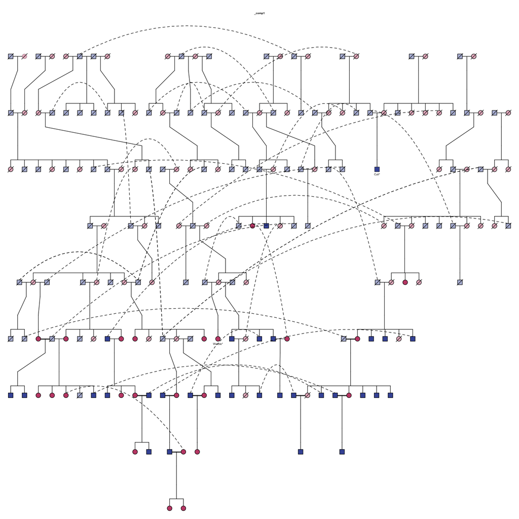

```r
ped_plot <- plot_pedigree(pedigree, studbook, labs_spec = TRUE)
ped_plot
```

And to download this as a single html file we can use the function below.

```r
pedsave(pedigree, studbook, labs_spec = TRUE)
```

#### Interactive Pedigree Graphics

We can also adapt `visNetwork` functions to render javascript-based graphics to represent the pedigree relationships built by `pedtools.`

```r
vis_pedigree <- visPed_tree(studbook, pedigree)
vis_pedigree
```

[interactive chart not shown]

You can use the optional parameter `variable` in that function to change the filtering options in the dropdown menu to highlight a subset of the nodes.

```r
vis_pedigree_year <- visPed_tree(studbook, pedigree, variable = "Year_birth")
vis_pedigree_year
```

[interactive chart not shown]

The best way to save interactive graphics like this is as an html file. `visNetwork` already has a function to make this easy.

```r
visSave(vis_pedigree,
        "visPed_tree_tutorial.html",
        selfcontained = TRUE)
```